# Relative Abundance and Bubble plots

# Relative Abundance and Bubble Plots

### Relative abundance plots vs bubble plots:

Both of these plots show the relative abundance of at least some taxa. Beyond the obvious difference of one being a stacked barplot and the other being a bubble plot, the key difference between the two is that relative abundance plots show the whole story of what is present in the samples, whereas bubble plots only show the key taxa, usually the significant taxa pulled out by a simper, ancom, or corncob analysis. Relative abundance plots are most useful when you want to look at compositional differences among samples, they can also give a very rough sense of the diversity in your samples. Bubble plots are most useful when you want to look at differences in abundance of key taxa. However, the bar plots can also pick out key taxa and just visualize those.

## load packages

```r
library("ggplot2")
library("phyloseq")
library("RColorBrewer")
library("reshape2")
library("nlme")
library("dplyr")
library("compositions")
library("tidyverse")
```

## load the files needed

```r
ps <- readRDS("examplePhyloseq.rds") #import the .rds phyloseq object made in the intro to phyloseq notebook
ps #confirm it worked
```

```
phyloseq-class experiment-level object
otu_table()   OTU Table:         [ 234 taxa and 64 samples ]
sample_data() Sample Data:       [ 64 samples by 13 sample variables ]
tax_table()   Taxonomy Table:    [ 234 taxa by 7 taxonomic ranks ]
```

### Add information to taxonomy

|  | Kingdom | Phylum | Class | Order | Family | Genus | Species |
| --- | --- | --- | --- | --- | --- | --- | --- |
| ASV_1 | Bacteria | Proteobacteria | Alphaproteobacteria | Rickettsiales | Midichloriaceae | Aquarickettsia | Aquarickettsia |
| ASV_2 | Bacteria | Spirochaetes | Spirochaetia | Spirochaetales | Spirochaetaceae | Spirochaeta_2 | Genus_Spirochaeta_2 |
| ASV_3 | Bacteria | Proteobacteria | Phylum_Proteobacteria | Phylum_Proteobacteria | Phylum_Proteobacteria | Phylum_Proteobacteria | Phylum_Proteobacteria |
| ASV_4 | Bacteria | Spirochaetes | Spirochaetia | Spirochaetales | Spirochaetaceae | Spirochaeta_2 | Genus_Spirochaeta_2 |
| ASV_5 | Bacteria | Proteobacteria | Alphaproteobacteria | Rickettsiales | Midichloriaceae | Aquarickettsia | Aquarickettsia |
| ASV_6 | Bacteria | Proteobacteria | Alphaproteobacteria | Class_Alphaproteobacteria | Class_Alphaproteobacteria | Class_Alphaproteobacteria | Class_Alphaproteobacteria |

## Relative Abundance plots

What goes in: a phyloseq object What goes out: a relative abundance plot

### Get the data in the right format for plotting

|  | taxa | sample | relab | Class | Sample.ID | Orig_geno_ID | X2020_Mote_ID | Genotype | Outlier | sampling_date | Species | Lat | Long | Region | collection_date | Baums_MSAT_clonal_ID | Proposed_pheno | Site |
| --- | --- | --- | --- | --- | --- | --- | --- | --- | --- | --- | --- | --- | --- | --- | --- | --- | --- | --- |
| 1 | ASV_1 | AC1.4 | 98.93320 | Alphaproteobacteria | AC1.4 | 1 | M-L-1 | 1.4 | No | 11/12/19 | cervicornis | 24.56937 | -81.33028 | Lower Keys | 2/23/08 | C1153 (AF) | Susceptible | Lower Keys |
| 2 | ASV_1 | AC10.4 | 99.40802 | Alphaproteobacteria | AC10.4 | 10 | M-L-10 | 10.4 | No | 11/12/19 | cervicornis | 24.61515 | -81.37917 | Lower Keys | 2/23/08 | C1083 (DG) | Susceptible | Lower Keys |
| 3 | ASV_1 | AC13.22 | 95.54299 | Alphaproteobacteria | AC13.22 | 13 | M-L-13 | 13.22 | No | 11/12/19 | cervicornis | 24.59592 | -81.37162 | Lower Keys | 12/1/09 | C1365 | Susceptible | Lower Keys |
| 4 | ASV_1 | AC20 | 94.88842 | Alphaproteobacteria | AC20 | 20 | M-L-20 | 20 | No | 12/13/19 | cervicornis | 24.62167 | -81.36313 | Lower Keys | 12/15/09 | C1191 | Susceptible | Lower Keys |
| 5 | ASV_1 | AC29 | 98.29620 | Alphaproteobacteria | AC29 | 29 | M-L-29 | 29 | No | 12/13/19 | cervicornis | 24.52172 | -81.57675 | Lower Keys | 5/28/10 | C1377 | NA | Lower Keys |
| 6 | ASV_1 | AC31.15 | 99.25272 | Alphaproteobacteria | AC31.15 | 31 | M-L-31 | 31.15 | No | 11/12/19 | cervicornis | 24.54770 | -81.45696 | Lower Keys | 3/18/10 | C1369 | Susceptible | Lower Keys |

### Setup your colors

```r
mycolors #confirm it worked
```

```
        <1% abundance   Alphaproteobacteria
               "grey"                 "red"
           Clostridia   Deltaproteobacteria
             "orange"              "yellow"
        Fusobacteriia      Oxyphotobacteria
              "green"                "blue"
Phylum_Proteobacteria          Spirochaetia
            "magenta"         "darkorchid4"
```

### Plot!

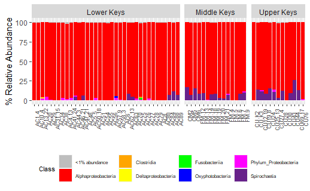

## Bubble plots

Bubble plots with ASVs on the y-axis

### Bubble plot with ASVs on the y-axis

What goes in: a phyloseq object What goes out: a bubble plot where significant ASVs is the y-axis ASVs pulled from simper

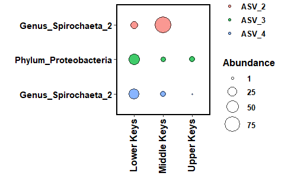